# Topic 1 Exercises

## Discussion Questions

### ISL 2.4.1

For each parts (a) through (d), indicate whether we would generally expect the performance of a flexible statistical learning method to be better or worse than an inflexible method.

1. The sample size *n* is extremely large and the number of predictors *p* is small.

I would expect the performance of a flexible statistical learning method to perform better. It will fit the data closer and perform better given the large sample size.

2. The number of predictors *p* is extremely large and the number of observations *n* is small.

I would expect the performance of a flexible statistical learning method to perform worse in this situation. A flexible method would overfit the small number of observations and follow the errors too closely.

3. The relationship between the predictors and response is highly non-linear.

I would expect the performance of a flexible statistical learning method to perform better. The flexible model has more degrees of freedom which will allow it to take on a non-linear shape.

4. The variance of the error terms is extremely high.

I would expect the performance of a flexible statistical learning method to perform worse than an inflexible model. Once again, a flexible model would follow the errors or noise too closely and increase variance.

### ISL 2.4.3

We now revisit the bias-variance decomposition.

1. Provide a sketch of typical (squared) bias, variance, training error, test error, and Bayes (or irreducible) error curves, on a single plot, as we go from less flexible statistical learning methods towards more flexible approaches. The x-axis should represent the amount of flexibility in the method, and the y-axis should represent the values for each curve. There should be five curves. Make sure to label each one.

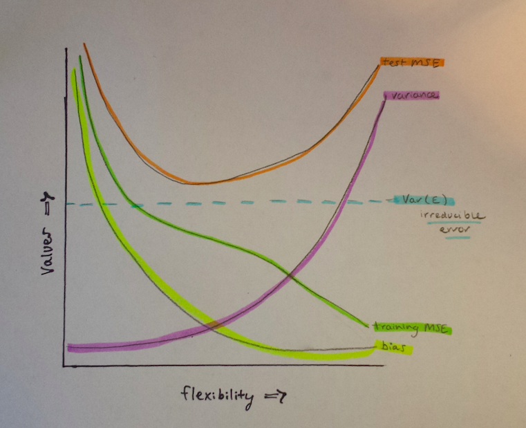

Sketch of typical bias, variance, training error, test error, and irreducible error

2. Explain why each of the five curves has the shape displayed in part (a).

Training MSE and Testing MSE: As flexibility increases, there is a monotone decrease in the training MSE and a U-shape in the test MSE. These properties hold true regardless of the data set and statistical method used. The training MSE decreases in this fashion because as flexibility increases the $f$ curve fits the data more closely. The test MSE initially decreases and levels off, but then increases again to form a U-shape as flexibility increases. It is key to note that as flexibility increases, training MSE will always decrease, but test MSE may not. If a method produces a small training MSE but a large test MSE, the data is getting overfitted (procedure working too hard to find patterns in training data and may be picking up patterns caused by random chance).

Typical bias and Variance: The typical (squared) bias decreases as flexibility increases where as variance increases as flexibility increases. This can be taken as a general rule. Variance is the amount by which $f$ hat, our estimate for $f$, would change if we estimated it using a different training data set. If the curve fits the data closely, then changing any data point may cause the estimate for $f$ hat to change drastcially and will result in variance. Bias is the error that is introduced by approximating a real-life problem by a simpler model. For example, if we choose to use a simple linear regression model, it is highly unlikely that a real-life problem has this type of simple relationship. Performing linear regression will result in bias in the estimatation of $f$.

Irreducible error: Irreducible error is a constant, thus it is modeled as a horizontal line in my sketch. It is below the test MSE curve because it represents the lowest achievable test MSE among all possible methods.

### ISL 2.4.6

Describe the differences between a parametric and a non-parametric statistical learning approach. What are the advantages of a parametric approach to regression or classification (as opposed to a nonparametric approach)? What are its disadvantages?

A parametric statistical learning approach reduces the problem of estimating $f$ down to one of estimating a set of parameters. It assumes a parametric form for $f$.

A non-parametric approach does not assume a patricular form of $f$. It requires a very large sample (large number of observations) to get a correct estimate of $f$.

The advantages of a parametric approach to regression or classification include simplifying the estimation of $f$ to a few parameters and requiring less observations than compared to a non-parametric approach.

The disadvantages of a parametric approach to regression or classification include a potentially inaccurate estimate of $f$ if the form of $f$ is too far from true $f$ or if more flexible models are used that lead to overfitting the data.